# Week5Lecture: Variance Components

Author

Lianne Sheppard for ENVH 556 Autumn 2024

Published

Invalid Date

This document was rendered on October 31, 2024.

# R commands & output for Variance Components Lecture Slides

```r
#-----DEMS data setup-----

# create the varaiable ln_ecdata among non-missing
# (`VCA::varPlot()` doesn't like tibbles)
DEMS <- DEMS %>%
    #as_tibble() %>%
    filter(ecdata > 0) %>%
    mutate(ln_ecdata = log(ecdata))
```

## slide 10: Plot the DEMS facility example

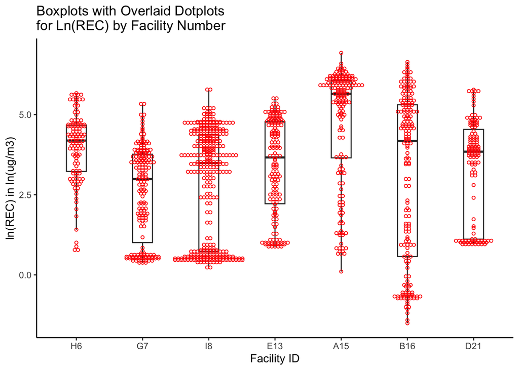

```r
#-----dotplot of DEMS-----

ggplot(DEMS, aes(x = facilityno, y = ln_ecdata)) +
    geom_boxplot(aes(x=facilityno, group = facilityno),
                 outlier.color = NA,
                 width = .3) +
    geom_dotplot(aes(group = facilityno), binaxis = "y", binwidth = .05,
                 stackdir =  "center", color = "red", fill = NA, dotsize = 2) +
    labs(title = "Boxplots with Overlaid Dotplots\nfor Ln(REC) by Facility Number",
         y = "ln(REC) in ln(ug/m3)",
         x = "Facility ID") +
    theme_classic()
```

## DEMS Stratified by facility ID (not a slide)

```r
#-----DEMS tidyverse stratified summary-----

# This compiles the results in one pipeline, labels the total properly, and shows the result because we didn't assign it a name
DEMS %>%
    # summary by facility
    group_by(facilityid) %>%
    summarise(N = n(),
              mean = mean(ln_ecdata),
              sd = sd(ln_ecdata),
              .groups = "drop") %>%

    # summary of all facilities
    bind_rows(DEMS %>% summarise(facilityid = "Total",
                                 N = n(),
                                 mean = mean(ln_ecdata),
                                 sd = sd(ln_ecdata) ) ) %>%
    # round
    mutate_if(is.double, round, 2)
```

```
# A tibble: 8 × 4
  facilityid     N  mean    sd
  <chr>      <int> <dbl> <dbl>
1 A            172  4.78  1.81
2 B            184  3.08  2.57
3 D            119  3.33  1.59
4 E            154  3.37  1.49
5 G            175  2.6   1.43
6 H            116  3.98  1.1
7 I            336  2.87  1.72
8 Total       1256  3.33  1.89
```

## Slide 12: Traffic gradient sites in the snapshot data

Plot the example of traffic gradient sites as an example of a single grouping variable in the snapshot data

```r
#-----Snapshot data setup-----

# The goal is to create a fall dataset for the variance components that
# identifies the gradient sites by keeping all observations that have more than
# 3 observations for the group_loc variable.  Note:  `fvc` is a tibble.  In the
# VCA package below it needs to be converted to a data frame.


fvc <- snapshot %>%
    filter(season == 2)  %>%
    group_by(group_loc) %>%
    mutate(count = n()) %>%
    ungroup() %>%
    filter(count > 3) %>%
    select(-count)
```

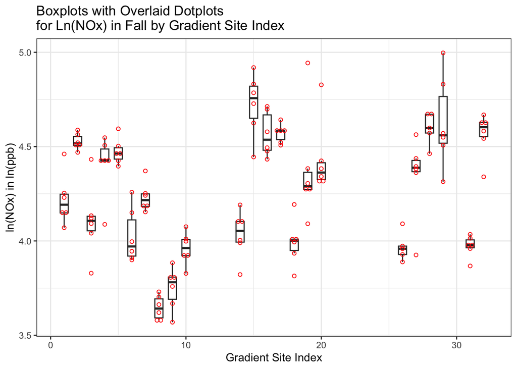

```r
#-----dotplot of fvc-----

ggplot(fvc, aes(x = group_loc, y = ln_nox)) +
    geom_boxplot(aes(x=group_loc, group = group_loc),
                 outlier.color = NA,
                 width = .6) +
    geom_dotplot(aes(group = group_loc), binaxis = "y", binwidth = .01,
                 stackdir =  "center", color = "red", fill = NA, dotsize = 2) +
        labs(title = "Boxplots with Overlaid Dotplots\nfor Ln(NOx) in Fall by Gradient Site Index",
         y = "ln(NOx) in ln(ppb)",
         x = "Gradient Site Index") +
    theme_bw()
```

## Slide 18: Snapshot data stratified by gradient site

```r
#-----tidyverse stratified summary snapshot-----

# One pipeline approach to coding this.  Note that since `vc_summary` is used
# later on, we need to filter out the "Total" row below
vc_summary <- fvc %>%
    group_by(group_loc) %>%
    summarise(N = n(),
              mean = mean(ln_nox),
              sd = sd(ln_nox)) %>%
    mutate(group_loc = as.character(group_loc) ) %>%
    bind_rows(fvc %>% summarise(group_loc = "Total",
                                N = n(),
                                mean = mean(ln_nox),
                                sd = sd(ln_nox) ) ) %>%
    mutate_if(is.double, round, 3)

# note we can omit the "digits = 3" option in kable because we already rounded
kable(vc_summary)
```

| group_loc | N | mean | sd |
| --- | --- | --- | --- |
| 1 | 6 | 4.219 | 0.135 |
| 2 | 6 | 4.527 | 0.043 |
| 3 | 6 | 4.108 | 0.194 |
| 4 | 6 | 4.403 | 0.163 |
| 5 | 6 | 4.474 | 0.069 |
| 6 | 6 | 4.027 | 0.146 |
| 7 | 6 | 4.232 | 0.078 |
| 8 | 6 | 3.646 | 0.063 |
| 9 | 6 | 3.749 | 0.113 |
| 10 | 6 | 3.960 | 0.087 |
| 14 | 6 | 4.036 | 0.128 |
| 15 | 6 | 4.722 | 0.168 |
| 16 | 6 | 4.565 | 0.118 |
| 17 | 6 | 4.571 | 0.049 |
| 18 | 6 | 3.992 | 0.123 |
| 19 | 6 | 4.379 | 0.293 |
| 20 | 6 | 4.435 | 0.197 |
| 26 | 5 | 3.968 | 0.076 |
| 27 | 6 | 4.344 | 0.217 |
| 28 | 5 | 4.596 | 0.087 |
| 29 | 6 | 4.628 | 0.245 |
| 31 | 6 | 3.972 | 0.058 |
| 32 | 6 | 4.565 | 0.118 |
| Total | 136 | 4.266 | 0.326 |

## Slide 19: Assessing between and within site variability

```r
#-----gradient variability-----

# create variance table after omitting the total row
vc_var <- vc_summary %>% filter(N < 100) %>%
    summarise(N_sites = n(),
              median_grand = median(mean),
              mean_grand = mean(mean),
              median_sd = median(sd),
              within_sd = sqrt(mean(sd^2)),
              between_sd = sd(mean)
              ) %>%
    mutate_if(is.double, round, 3)

# show table
vc_var
```

```
# A tibble: 1 × 6
  N_sites median_grand mean_grand median_sd within_sd between_sd
    <int>        <dbl>      <dbl>     <dbl>     <dbl>      <dbl>
1      23         4.34       4.27     0.118     0.144      0.304
```

```r
# paste a few numbers of interest
paste("Between-group variance estimate(SD scale) = ", round(vc_var$between_sd, 3))
```

```
[1] "Between-group variance estimate(SD scale) =  0.304"
```

```r
paste("Within-group  variance estimate(SD scale) = ", round(vc_var$within_sd, 3))
```

```
[1] "Within-group  variance estimate(SD scale) =  0.144"
```

```r
paste("Total         variance estimate(SD scale) = ", round(sqrt(vc_var$within_sd^2 +
                                                                    vc_var$between_sd^2), 3))
```

```
[1] "Total         variance estimate(SD scale) =  0.336"
```

## Dropped from lecture: Site as a fixed effect

Needs development to focus this result in comparison to the random effect result. Note that this is a regression model based approach to the previous more descriptive approach.

### Regression with site as a fixed effect

```r
#-----site as a fixed effect-----

# (formerly slide 16)

fixed_ef <- lm(ln_nox ~ as.factor(group_loc), data = fvc)
summary(fixed_ef)
```

```
Call:
lm(formula = ln_nox ~ as.factor(group_loc), data = fvc)

Residuals:
     Min       1Q   Median       3Q      Max
-0.41856 -0.07016  0.00459  0.06098  0.56463

Coefficients:
                       Estimate Std. Error t value Pr(>|t|)
(Intercept)             4.21926    0.05929  71.166  < 2e-16 ***
as.factor(group_loc)2   0.30737    0.08385   3.666 0.000377 ***
as.factor(group_loc)3  -0.11099    0.08385  -1.324 0.188255
as.factor(group_loc)4   0.18411    0.08385   2.196 0.030145 *
as.factor(group_loc)5   0.25489    0.08385   3.040 0.002940 **
as.factor(group_loc)6  -0.19249    0.08385  -2.296 0.023535 *
as.factor(group_loc)7   0.01244    0.08385   0.148 0.882356
as.factor(group_loc)8  -0.57350    0.08385  -6.840 4.28e-10 ***
as.factor(group_loc)9  -0.47034    0.08385  -5.610 1.46e-07 ***
as.factor(group_loc)10 -0.25962    0.08385  -3.096 0.002471 **
as.factor(group_loc)14 -0.18370    0.08385  -2.191 0.030511 *
as.factor(group_loc)15  0.50305    0.08385   6.000 2.43e-08 ***
as.factor(group_loc)16  0.34624    0.08385   4.129 6.99e-05 ***
as.factor(group_loc)17  0.35175    0.08385   4.195 5.45e-05 ***
as.factor(group_loc)18 -0.22684    0.08385  -2.705 0.007877 **
as.factor(group_loc)19  0.15945    0.08385   1.902 0.059750 .
as.factor(group_loc)20  0.21595    0.08385   2.576 0.011297 *
as.factor(group_loc)26 -0.25147    0.08794  -2.860 0.005054 **
as.factor(group_loc)27  0.12489    0.08385   1.489 0.139148
as.factor(group_loc)28  0.37654    0.08794   4.282 3.91e-05 ***
as.factor(group_loc)29  0.40895    0.08385   4.877 3.55e-06 ***
as.factor(group_loc)31 -0.24724    0.08385  -2.949 0.003879 **
as.factor(group_loc)32  0.34537    0.08385   4.119 7.27e-05 ***
---
Signif. codes:  0 '***' 0.001 '**' 0.01 '*' 0.05 '.' 0.1 ' ' 1

Residual standard error: 0.1452 on 113 degrees of freedom
Multiple R-squared:  0.8343,    Adjusted R-squared:  0.802
F-statistic: 25.86 on 22 and 113 DF,  p-value: < 2.2e-16
```

### Dropped from lecture: Same in ANOVA (fixed effect model)

```r
#-----ANOVA on site-----

# (formerly slide 17):  same in ANOVA
## The group_loc groups show significantly different mean ln_nox levels, indicating a meaningful relationship between these groupings and log NOx levels.
anova(fixed_ef)
```

```
Analysis of Variance Table

Response: ln_nox
                      Df  Sum Sq Mean Sq F value    Pr(>F)
as.factor(group_loc)  22 11.9965 0.54529  25.855 < 2.2e-16 ***
Residuals            113  2.3832 0.02109
---
Signif. codes:  0 '***' 0.001 '**' 0.01 '*' 0.05 '.' 0.1 ' ' 1
```

## Slide 21 + 22: Variance components with VCA

VCA allows the MOM estimates and easy comparison with REML estimates of variance components.

MOM is a simpler, often computationally faster method that may be okay if data are ‘simple.’

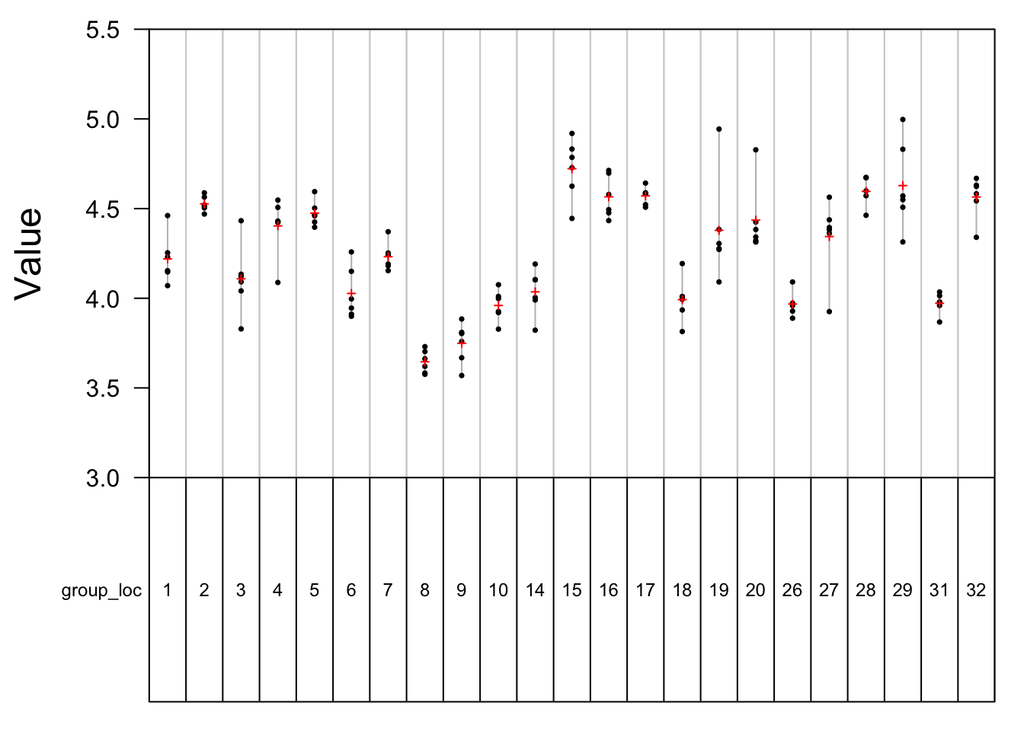

```r
#-----VCA implementation-----

# (slides 21+22)
# Note: the VCA package functions require data of class data.frame, not a
# tibble, so we've made that adjustment in the function arguments

# visualize data
varPlot(form = ln_nox~ group_loc, Data = as.data.frame(fvc) )
```

```r
# different ways to estimate variance components
fit_MOM <- anovaVCA(ln_nox ~ group_loc, Data = as.data.frame(fvc) )
fit_MOM
```

```
Result Variance Component Analysis:
-----------------------------------

  Name      DF        SS        MS       VC       %Total    SD       CV[%]
1 total     30.936703                    0.109751 100       0.331288 7.766199
2 group_loc 22        11.996454 0.545293 0.088661 80.783523 0.29776  6.980233
3 error     113       2.383212  0.02109  0.02109  19.216477 0.145225 3.404438

Mean: 4.265763 (N = 136)

Experimental Design: unbalanced  |  Method: ANOVA
```

```r
# NOTE: if you receive an error with fitVCA(), you may need to reinstall lme4
# install.packages("lme4", repos = "http://cran.r-project.org", type = "source")
fit_REML <- fitVCA(ln_nox ~ group_loc, Data = as.data.frame(fvc), method = "REML")
fit_REML
```

```
Result Variance Component Analysis:
-----------------------------------

  Name      DF         VC       %Total    SD       CV[%]    Var(VC)
1 total     30.918201  0.109881 100       0.331483 7.770776 0.000781
2 group_loc 20.323725  0.08879  80.805879 0.297977 6.985313 0.000776
3 error     113.000095 0.021091 19.194121 0.145226 3.404462 8e-06

Mean: 4.265763 (N = 136)

Experimental Design: unbalanced  |  Method: REML
```

```r
# the following gives the same result so is not repeated
#fit_ANOVA <- fitVCA(ln_nox ~ group_loc, Data = as.data.frame(fvc), method = "anova")
#fit_ANOVA
```

## Slides 23 & 24: Estimation using lme

A key point here that the **`lmer` REML estimates are the same as from `VCA`**. Discuss why we use ML at all – basically to easily compare models. Because REML adjusts for the bias in estimation, we can’t compare models fit with REML.

```r
#-----REML with snapshot-----

lmefit_REML <- lmer(ln_nox ~ (1|group_loc), data = fvc, REML = TRUE)
summary(lmefit_REML)
```

```
Linear mixed model fit by REML ['lmerMod']
Formula: ln_nox ~ (1 | group_loc)
   Data: fvc

REML criterion at convergence: -61.4

Scaled residuals:
    Min      1Q  Median      3Q     Max
-2.8616 -0.4796 -0.0212  0.3764  3.9175

Random effects:
 Groups    Name        Variance Std.Dev.
 group_loc (Intercept) 0.08879  0.2980
 Residual              0.02109  0.1452
Number of obs: 136, groups:  group_loc, 23

Fixed effects:
            Estimate Std. Error t value
(Intercept)  4.26598    0.06337   67.32
```

```r
#-----ML with snapshot-----

lmefit_ML <- lmer(ln_nox ~ (1|group_loc), data = fvc, REML = FALSE)
summary(lmefit_ML)
```

```
Linear mixed model fit by maximum likelihood  ['lmerMod']
Formula: ln_nox ~ (1 | group_loc)
   Data: fvc

     AIC      BIC   logLik deviance df.resid
   -59.1    -50.3     32.5    -65.1      133

Scaled residuals:
    Min      1Q  Median      3Q     Max
-2.8607 -0.4779 -0.0212  0.3764  3.9188

Random effects:
 Groups    Name        Variance Std.Dev.
 group_loc (Intercept) 0.08477  0.2912
 Residual              0.02109  0.1452
Number of obs: 136, groups:  group_loc, 23

Fixed effects:
            Estimate Std. Error t value
(Intercept)  4.26598    0.06198   68.83
```

## Same examples with DEMS

### Dropped from lecture: DEMS with VCA

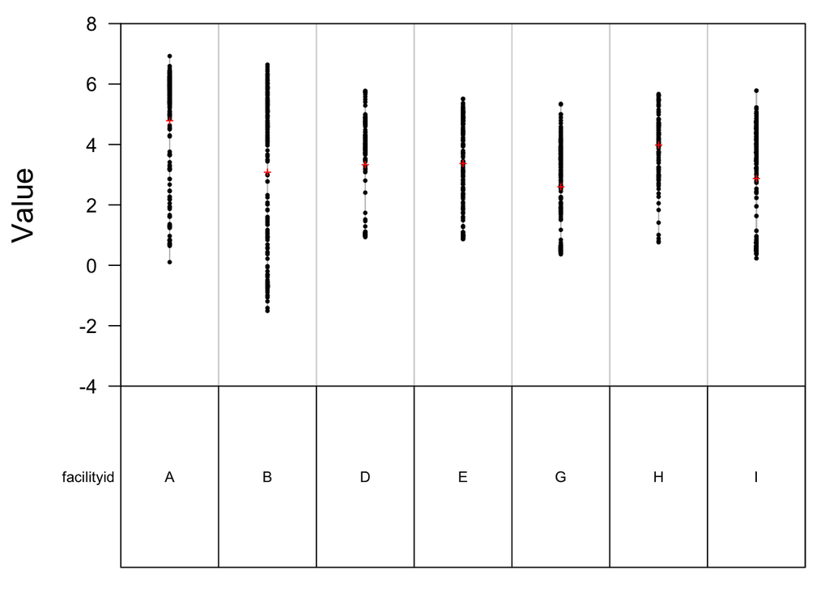

```r
#-----VCA implementation in DEMS-----

# (some results for slide 26 are included in this chunk)

# visualize data
varPlot(form = ln_ecdata ~ facilityid, Data = DEMS)
```

```r
## different ways to estimate variance components
fit_MOM <- anovaVCA(ln_ecdata ~ facilityid, Data = DEMS)
```

```
Convert variable facilityid from "character" to "factor"!
```

```r
fit_MOM
```

```
Result Variance Component Analysis:
-----------------------------------

  Name       DF         SS          MS        VC       %Total    SD
1 total      222.939402                       3.656123 100       1.912099
2 facilityid 6          588.297946  98.049658 0.542309 14.832894 0.736416
3 error      1249       3889.153458 3.113814  3.113814 85.167106 1.7646
  CV[%]
1 57.355292
2 22.089528
3 52.93092

Mean: 3.33378 (N = 1256)

Experimental Design: unbalanced  |  Method: ANOVA
```

```r
fit_REML <- fitVCA(ln_ecdata ~ facilityid, Data = DEMS, method = "REML")
```

```
Convert variable facilityid from "character" to "factor"!
```

```r
fit_REML
```

```
Result Variance Component Analysis:
-----------------------------------

  Name       DF          VC       %Total   SD       CV[%]     Var(VC)
1 total      229.658035  3.64288  100      1.908633 57.251325 0.115568
2 facilityid 5.585885    0.529102 14.52429 0.727394 21.818907 0.100235
3 error      1249.000512 3.113777 85.47571 1.76459  52.93061  0.015525

Mean: 3.33378 (N = 1256)

Experimental Design: unbalanced  |  Method: REML
```

```r
fit_ANOVA <- fitVCA(ln_ecdata ~ facilityid, Data = DEMS, method = "anova")
```

```
Convert variable facilityid from "character" to "factor"!
```

```r
fit_ANOVA
```

```
Result Variance Component Analysis:
-----------------------------------

  Name       DF         SS          MS        VC       %Total    SD
1 total      222.939402                       3.656123 100       1.912099
2 facilityid 6          588.297946  98.049658 0.542309 14.832894 0.736416
3 error      1249       3889.153458 3.113814  3.113814 85.167106 1.7646
  CV[%]
1 57.355292
2 22.089528
3 52.93092

Mean: 3.33378 (N = 1256)

Experimental Design: unbalanced  |  Method: ANOVA
```

### Slide 26: DEMS comparison of estimates

I did not develop all the R coding for this. In this section we would need to use the code for the snapshot data, now applied to DEMS.

## Slide 32: Mixed model with the Snapshot data: Pop_5000 as one fixed covariate

The following analyses address how the two variance components change when different covariates are in the model. As was done in the Peretz paper, think about whether we expect an impact on the variance components and whether the impact should affect the between site or within site variance estimates.

Note: Because one might want to do some model selection comparisons with these analyses, I used the ML option (i.e. REML = FALSE).

```r
#-----mixed model with Pop_5000-----

mixedfit1_ML <- lmer(ln_nox ~ Pop_5000 + (1|group_loc), data = fvc, REML = FALSE)
summary(mixedfit1_ML)
```

```
Linear mixed model fit by maximum likelihood  ['lmerMod']
Formula: ln_nox ~ Pop_5000 + (1 | group_loc)
   Data: fvc

     AIC      BIC   logLik deviance df.resid
   -71.5    -59.9     39.8    -79.5      132

Scaled residuals:
    Min      1Q  Median      3Q     Max
-2.8204 -0.4959 -0.0268  0.3736  3.8881

Random effects:
 Groups    Name        Variance Std.Dev.
 group_loc (Intercept) 0.04244  0.2060
 Residual              0.02119  0.1456
Number of obs: 136, groups:  group_loc, 23

Fixed effects:
            Estimate Std. Error t value
(Intercept)   3.7739     0.1172  32.189
Pop_5000      0.1576     0.0347   4.541

Correlation of Fixed Effects:
         (Intr)
Pop_5000 -0.924
```

## Slide 33: Mixed model with the Snapshot data: D2R as one fixed covariate

```r
#-----mixed model with D2R-----

mixedfit2_ML <- lmer(ln_nox ~ D2R + (1|group_loc), data = fvc, REML = FALSE)
summary(mixedfit2_ML)
```

```
Linear mixed model fit by maximum likelihood  ['lmerMod']
Formula: ln_nox ~ D2R + (1 | group_loc)
   Data: fvc

     AIC      BIC   logLik deviance df.resid
   -80.8    -69.1     44.4    -88.8      132

Scaled residuals:
    Min      1Q  Median      3Q     Max
-2.6732 -0.4924  0.0695  0.4784  3.3774

Random effects:
 Groups    Name        Variance Std.Dev.
 group_loc (Intercept) 0.08190  0.2862
 Residual              0.01724  0.1313
Number of obs: 136, groups:  group_loc, 23

Fixed effects:
            Estimate Std. Error t value
(Intercept)  4.54750    0.08195  55.491
D2R         -0.14402    0.02815  -5.116

Correlation of Fixed Effects:
    (Intr)
D2R -0.671
```

## Dropped from lecture: Mixed model with the Snapshot data: two covariates

Note: to compare models you need to use ML because of how the variance components are estimated to be unbiased in REML. For final estimates we should report REML.

```r
#-----mixed with two covars-----

mixedfit3_ML <- lmer(ln_nox ~ Pop_5000 + D2Comm + (1|group_loc), data = fvc, REML = FALSE)
summary(mixedfit3_ML)
```

```
Linear mixed model fit by maximum likelihood  ['lmerMod']
Formula: ln_nox ~ Pop_5000 + D2Comm + (1 | group_loc)
   Data: fvc

     AIC      BIC   logLik deviance df.resid
   -75.4    -60.8     42.7    -85.4      131

Scaled residuals:
    Min      1Q  Median      3Q     Max
-2.4663 -0.5319 -0.0372  0.3137  3.8509

Random effects:
 Groups    Name        Variance Std.Dev.
 group_loc (Intercept) 0.03510  0.1874
 Residual              0.02085  0.1444
Number of obs: 136, groups:  group_loc, 23

Fixed effects:
            Estimate Std. Error t value
(Intercept)  3.85302    0.11231  34.307
Pop_5000     0.15701    0.03184   4.931
D2Comm      -2.74215    1.09833  -2.497

Correlation of Fixed Effects:
         (Intr) P_5000
Pop_5000 -0.889
D2Comm   -0.288  0.014
```

## Slide 36: Regression for association with random effects

Use the snapshot data to compare estimates and SEs for a fixed effect with and without random effects

```r
#-----mixed model vs lm-----

# Compare estimates and SEs
# linear model:
lmfit1 <- lm(ln_nox ~ Pop_5000, data = fvc)

# summary(lmfit1)

cat("\nStandard linear model summary, coefficients then their confidence intervals\n")
```

```
Standard linear model summary, coefficients then their confidence intervals
```

```r
coef(summary(lmfit1))
```

```
             Estimate Std. Error   t value      Pr(>|t|)
(Intercept) 3.7639204 0.05768948 65.244483 2.039489e-103
Pop_5000    0.1602903 0.01705876  9.396368  2.020773e-16
```

```r
confint(lmfit1)
```

```
                2.5 %    97.5 %
(Intercept) 3.6498206 3.8780201
Pop_5000    0.1265511 0.1940296
```

```r
# mixed model
mixedfit1_REML <- lmer(ln_nox ~ Pop_5000 + (1|group_loc), data = fvc, REML = TRUE)

#summary(mixedfit1_REML)
cat("\nMixed model summary using REML, coefficients then their confidence intervals\n")
```

```
Mixed model summary using REML, coefficients then their confidence intervals
```

```r
coef(summary(mixedfit1_REML))
```

```
             Estimate Std. Error   t value
(Intercept) 3.7749422 0.12253748 30.806430
Pop_5000    0.1572473 0.03626669  4.335861
```

```r
confint(mixedfit1_REML)
```

```
Computing profile confidence intervals ...
```

```
                 2.5 %    97.5 %
.sig01      0.15344615 0.2893012
.sigma      0.12846405 0.1668176
(Intercept) 3.53638145 4.0153691
Pop_5000    0.08607396 0.2278337
```

Note (not necessarily discussed in lecture): The fixed effect estimates will change when there is correlation between fixed and random effect parts of the model. Random effects do not address residual confounding. The most appropriate assumption is to assume the random effects are independent of the fixed effects. In the following example there appears to be some correlation between the *D2Comm* variable and the random effects, leading to a change in the coefficient estimate for *D2Comm* between the fixed and mixed models.

```r
#-----mixed model vs lm: 2 covars-----

# Compare estimates and SEs
# linear model:
lmfit2 <- lm(ln_nox ~ Pop_5000 + D2Comm, data = fvc)

cat("\nStandard linear model summary, coefficients then their confidence intervals\n")
```

```
Standard linear model summary, coefficients then their confidence intervals
```

```r
coef(summary(lmfit2))
```

```
              Estimate Std. Error   t value      Pr(>|t|)
(Intercept)  3.8796942 0.05982918 64.846186 1.592398e-102
Pop_5000     0.1592379 0.01596077  9.976832  7.649683e-18
D2Comm      -3.9670948 0.88477753 -4.483720  1.568383e-05
```

```r
confint(lmfit2)
```

```
                 2.5 %     97.5 %
(Intercept)  3.7613544  3.9980340
Pop_5000     0.1276681  0.1908077
D2Comm      -5.7171505 -2.2170392
```

```r
# mixed model
mixedfit2_REML <- lmer(ln_nox ~ Pop_5000 + D2Comm + (1|group_loc), data = fvc, REML = TRUE)

cat("\nMixed model summary using REML, coefficients then their confidence intervals\n")
```

```
Mixed model summary using REML, coefficients then their confidence intervals
```

```r
coef(summary(mixedfit2_REML))
```

```
              Estimate Std. Error   t value
(Intercept)  3.8525570  0.1180339 32.639424
Pop_5000     0.1566911  0.0335512  4.670208
D2Comm      -2.6898177  1.1187890 -2.404223
```

```r
confint(mixedfit2_REML)
```

```
Computing profile confidence intervals ...
```

```
                  2.5 %     97.5 %
.sig01       0.13818483  0.2648395
.sigma       0.12740597  0.1655308
(Intercept)  3.62382034  4.0809102
Pop_5000     0.09135949  0.2215579
D2Comm      -4.92300306 -0.5309150
```

## Slide 37: Regression for prediction with random effects

To predict from a mixed model, i.e. a linear model with fixed and random effects, you MUST have the same groups as you used to fit your model. You can’t predict on new groups. Thus random effects models are less commonly used in prediction problems than other kinds of variance models (e.g. geostatistical models).

When you predict from a mixed model, you need to decide whether you want to only predict the fixed effects, or incorporate the random effects into the predictions.

The following shows full predictions (fixed+random) and then fixed effect only predictions in the snapshot gradient site data for the mixed effect model with only one covariate:

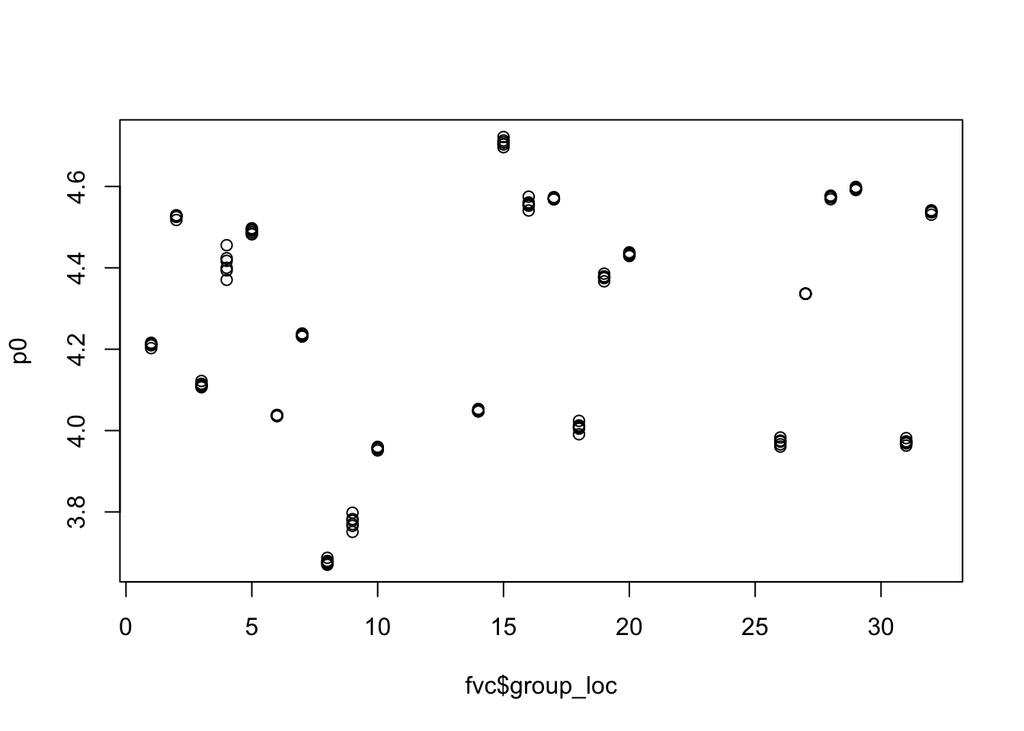

```r
#-----mixed effects model prediction on same data-----

# Prediction incorporating fixed & random effects
p0 <- predict(mixedfit1_REML)
plot(fvc$group_loc,p0)
```

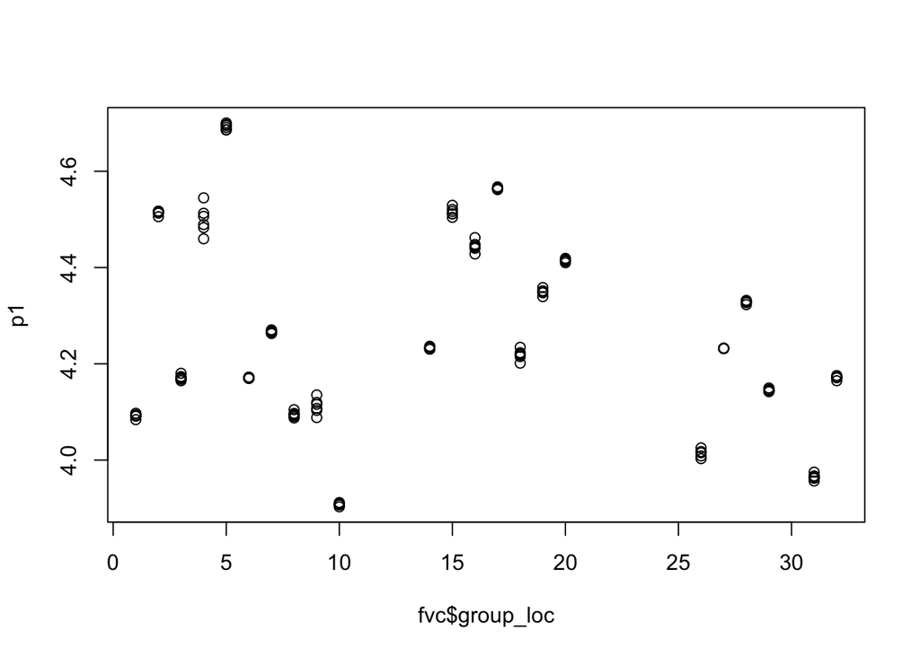

```r
# Predictions of fixed effects only
# The re.form = NA option omits random effects
p1 <- predict(mixedfit1_REML, re.form = NA)
plot(fvc$group_loc,p1)
```

```r
identical(p0,p1)
```

```
[1] FALSE
```

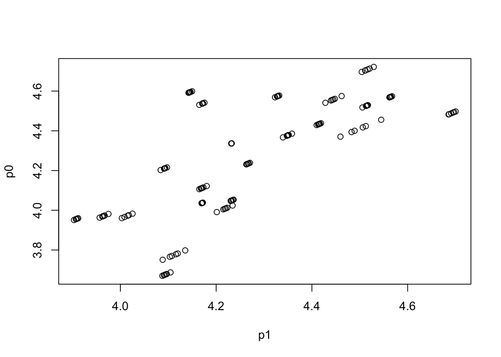

```r
plot(p1,p0)
```

```r
# Note the predictions with random effects are more variable, as one would expect.
summary(p1)
```

```
   Min. 1st Qu.  Median    Mean 3rd Qu.    Max.
  3.903   4.131   4.232   4.267   4.441   4.700
```

```r
summary(p0)
```

```
   Min. 1st Qu.  Median    Mean 3rd Qu.    Max.
  3.670   4.021   4.336   4.266   4.532   4.722
```

When you predict in a new dataset from a mixed model, you MUST have all grouping variables and random effects used in the model fitting. However, if you don’t want to predict at all groups, you can set their values to NA. For details, see this [predict.merMod help page](https://www.rdocumentation.org/packages/lme4/versions/1.1-19/topics/predict.merMod).

For example, to predict at one location per gradient site in the snapshot data:

```r
#-----mixed effects model prediction on new data-----

newdata <- with(fvc, expand.grid(Pop_5000=unique(Pop_5000),
                                 group_loc=unique(group_loc)))
dim(newdata)
```

```
[1] 3128    2
```

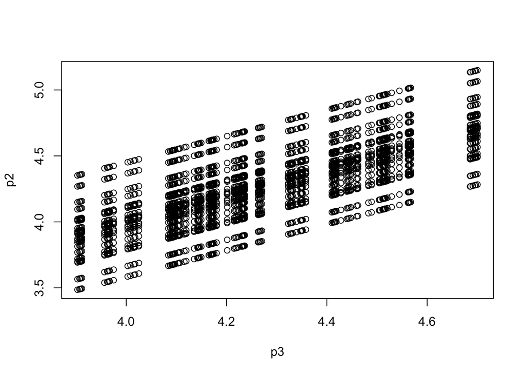

```r
# new data, all RE
p2 <- predict(mixedfit1_REML, newdata)

# new data, level 0 (fixed effects only)
p3 <- predict(mixedfit1_REML, newdata, re.form = NA)

plot(p3, p2)
```

```r
# Note the predictions with random effects are more variable, as one would expect.
summary(p3)
```

```
   Min. 1st Qu.  Median    Mean 3rd Qu.    Max.
  3.903   4.131   4.232   4.267   4.441   4.700
```

```r
summary(p2)
```

```
   Min. 1st Qu.  Median    Mean 3rd Qu.    Max.
  3.486   4.078   4.251   4.267   4.466   5.149
```

## DEMS V results moved to extra lecture slides, slides 44-46

### Slide 44: DEMS V Table 3 Facility A example U1 groups

Verifying: This result has the same number of observations (108) and mdj groups (13) compared to the Stata example from lecture. My mean is about the same (5.85). This seems to be the same dataset

```r
#-----model DEMSV_U1-----

DEMSV_U1 <- lmer(ln_ecdata ~  (1|mdj), data = DEMS, REML = TRUE,
                 subset = facilityid == "A" & u_s == "u")

summary(DEMSV_U1)
```

```
Linear mixed model fit by REML ['lmerMod']
Formula: ln_ecdata ~ (1 | mdj)
   Data: DEMS
 Subset: facilityid == "A" & u_s == "u"

REML criterion at convergence: 158

Scaled residuals:
    Min      1Q  Median      3Q     Max
-4.3659 -0.4216  0.1679  0.6403  2.1445

Random effects:
 Groups   Name        Variance Std.Dev.
 mdj      (Intercept) 0.004851 0.06965
 Residual             0.241493 0.49142
Number of obs: 108, groups:  mdj, 13

Fixed effects:
            Estimate Std. Error t value
(Intercept)  5.85041    0.05275   110.9
```

## Slides 45: DEMS V Table 3 Facility A example U2 groups

```r
#-----model DEMSV_U2-----

DEMSV_U2 <- lmer(ln_ecdata ~  as.factor(group2time) + (1|mdj), data = DEMS,
                 REML = TRUE, subset = facilityid == "A" & u_s == "u")

summary(DEMSV_U2)
```

```
Linear mixed model fit by REML ['lmerMod']
Formula: ln_ecdata ~ as.factor(group2time) + (1 | mdj)
   Data: DEMS
 Subset: facilityid == "A" & u_s == "u"

REML criterion at convergence: 162.7

Scaled residuals:
    Min      1Q  Median      3Q     Max
-4.2080 -0.4168  0.2239  0.6019  2.0779

Random effects:
 Groups   Name        Variance Std.Dev.
 mdj      (Intercept) 0.02557  0.1599
 Residual             0.23787  0.4877
Number of obs: 108, groups:  mdj, 13

Fixed effects:
                        Estimate Std. Error t value
(Intercept)             5.821414   0.123792  47.026
as.factor(group2time)2  0.203454   0.254325   0.800
as.factor(group2time)3  0.008459   0.206445   0.041
as.factor(group2time)6 -0.052423   0.176041  -0.298
as.factor(group2time)7  0.168277   0.252758   0.666

Correlation of Fixed Effects:
            (Intr) a.(2)2 a.(2)3 a.(2)6
as.fctr(2)2 -0.487
as.fctr(2)3 -0.600  0.292
as.fctr(2)6 -0.703  0.342  0.422
as.fctr(2)7 -0.490  0.238  0.294  0.344
```

## Slide 46: DEMS V Table 3 Facility A example U3 groups

```r
#-----model DEMSV_U3-----

DEMSV_U3 <- lmer(ln_ecdata ~  as.factor(group3area) + (1|mdj), data = DEMS,
                 REML = TRUE, subset = facilityid == "A" & u_s == "u")

summary(DEMSV_U3)
```

```
Linear mixed model fit by REML ['lmerMod']
Formula: ln_ecdata ~ as.factor(group3area) + (1 | mdj)
   Data: DEMS
 Subset: facilityid == "A" & u_s == "u"

REML criterion at convergence: 161.9

Scaled residuals:
    Min      1Q  Median      3Q     Max
-4.2635 -0.4376  0.1746  0.6538  2.1955

Random effects:
 Groups   Name        Variance Std.Dev.
 mdj      (Intercept) 0.006497 0.0806
 Residual             0.243225 0.4932
Number of obs: 108, groups:  mdj, 13

Fixed effects:
                       Estimate Std. Error t value
(Intercept)             5.80963    0.09314  62.373
as.factor(group3area)2  0.11825    0.14168   0.835
as.factor(group3area)4  0.02380    0.12729   0.187

Correlation of Fixed Effects:
            (Intr) a.(3)2
as.fctr(3)2 -0.657
as.fctr(3)4 -0.732  0.481
```